# Dự đoán tỷ lệ tội phạm bạo lực trong các cộng đồng Hoa Kỳ

## 22.4 Đánh giá và lựa chọn mô hình

RMSE là tiêu chí lựa chọn chính; MAE, MAPE và R² bổ sung thông tin về độ lớn, tỷ lệ sai số và khả năng giải thích ngoài mẫu.

```r
RMSE <- function(y, p) {
  sqrt(mean((y - p)^2))
}

MAE <- function(y, p) {
  mean(abs(y - p))
}

MAPE <- function(y, p) {
  mean(abs((y - p) / y)) * 100
}

R2 <- function(y, p) {
  1 - sum((y - p)^2) /
    sum((y - mean(y))^2)
}

stopifnot(
  all(y_validation != 0)
)

validation_result <- data.frame(
  Model = c(
    "OLS",
    "Ridge Regression",
    "LASSO Regression"
) ,
  RMSE = c(
    RMSE(y_validation, pred_ols),
    RMSE(y_validation, pred_ridge),
    RMSE(y_validation, pred_lasso)
  ),
  MAE = c(
    MAE(y_validation, pred_ols),
    MAE(y_validation, pred_ridge),
    MAE(y_validation, pred_lasso)
  ),
  MAPE = c(
    MAPE(y_validation, pred_ols),
    MAPE(y_validation, pred_ridge),
    MAPE(y_validation, pred_lasso)
  ),
  R2 = c(
    R2(y_validation, pred_ols),
    R2(y_validation, pred_ridge),
    R2(y_validation, pred_lasso)
  )
)

best_index <- which.min(validation_result$RMSE)
best_model <- validation_result$Model[best_index]
rmse_gaps <- validation_result$RMSE - min(validation_result$RMSE)

print(validation_result)
```

```
##              Model     RMSE      MAE     MAPE        R2
## 1              OLS 53339.41 35204.30 56.99144 0.3719520
## 2 Ridge Regression 53172.54 34948.09 59.50827 0.3758754
## 3 LASSO Regression 53338.39 34934.42 62.74898 0.3719760
```

**Kết luận chung về các mô hình hồi quy.**

Trên validation set, Ridge Regression có RMSE thấp nhất, bằng $53,173, tiếp theo là LASSO Regression với $53,338 và OLS với $53,339. Ridge Regression giảm RMSE khoảng $167 so với OLS và $166 so với LASSO Regression, tương ứng mức cải thiện khoảng 0,31%. Vì vậy, Ridge Regression được lựa chọn theo tiêu chí RMSE đã xác định trước, nhưng khoảng cách này quá nhỏ để kết luận mô hình vượt trội về mặt thực tiễn. LASSO Regression có MAE thấp nhất, Ridge Regression có R² cao nhất và OLS có MAPE thấp nhất; không mô hình nào cho kết quả tốt nhất ở toàn bộ chỉ số.

Nhìn chung, cả ba mô hình tạo ra khả năng dự báo ở mức vừa phải và có thể được sử dụng làm các mô hình nền. R² và R² hiệu chỉnh của mô hình OLS trên training set lần lượt bằng 0,489 và 0,469, phản ánh mức độ phù hợp trong dữ liệu dùng để ước lượng. Các giá trị R² từ 0,372 đến 0,376 trên validation set cho thấy các biến đầu vào giải thích được hơn một phần ba biến thiên mức lương ngoài mẫu so với phương án dùng mức lương trung bình thực tế của validation set làm dự báo cho mọi quan sát. MAE khoảng $35,000 và RMSE khoảng $53,000 cho thấy sai số dự báo vẫn còn đáng kể, do đó các mô hình mới nhận diện được một phần cấu trúc của mức lương. Trong bối cảnh mức lương trung vị của toàn bộ mẫu là $100,000, quy mô MAE và RMSE cho thấy độ lệch dự báo không nhỏ.

Hiệu quả gần tương đương giữa OLS, Ridge Regression và LASSO Regression có thể liên quan đến việc ba mô hình sử dụng cùng tập biến đầu vào và cùng cấu trúc tuyến tính cộng. Ridge Regression và LASSO Regression thay đổi cách ước lượng hệ số thông qua điều chuẩn nhưng không bổ sung thông tin mới, quan hệ phi tuyến hoặc thành phần tương tác. Bên cạnh đó, các GVIF hiệu chỉnh đều gần 1 và 17 biến sau mã hóa không lớn so với 452 quan sát trong training set, nên lợi ích của điều chuẩn đối với đa cộng tuyến và độ phức tạp mô hình có khả năng bị giới hạn. Phân phối mức lương lệch phải, có độ phân tán lớn và vẫn giữ các mức lương ngoại lai hợp lý, khiến RMSE nhạy với một số sai số lớn. Dữ liệu đầu vào chủ yếu gồm các nhóm phân loại tương đối rộng và không có những thông tin chi tiết như số năm kinh nghiệm thực tế, trình độ học vấn, kỹ năng chuyên môn, quốc gia hoặc thành phố cụ thể, ngành hoạt động và đặc điểm riêng của doanh nghiệp; sự thiếu vắng này có thể giới hạn khả năng giải thích và dự báo của cả ba mô hình. Kết quả cũng dựa trên một lần chia training–validation, vì vậy mức chênh lệch rất nhỏ giữa ba mô hình không nên được diễn giải quá mức.

Mặc dù Ridge Regression được lựa chọn làm mô hình hồi quy đại diện theo tiêu chí RMSE, OLS vẫn phù hợp hơn cho việc diễn giải các đặc điểm liên hệ với mức lương vì hệ số được trình bày trực tiếp theo nhóm tham chiếu và đi kèm các kết quả suy luận thống kê. Như đã trình bày trong phần OLS, cấp kinh nghiệm và khu vực cư trú là hai nhóm đặc điểm tạo ra chênh lệch rõ nhất, tiếp theo là lĩnh vực nghề nghiệp và quy mô công ty. Các hệ số của Ridge nhìn chung giữ nguyên chiều và thứ tự tương đối của những mẫu hình chính sau điều chuẩn, cho thấy kết luận không phụ thuộc hoàn toàn vào một phương pháp ước lượng duy nhất. Tuy nhiên, các hệ số chỉ phản ánh mối liên hệ sau khi đồng thời xét các biến còn lại, không phải tác động nhân quả.

OLS có ưu điểm lớn nhất về khả năng diễn giải và suy luận thống kê thông qua hệ số, p-value, F-test và Type II ANOVA, nhưng không điều chuẩn hệ số và bị giới hạn bởi cấu trúc tuyến tính cộng. Ridge Regression cải thiện độ ổn định thông qua khoản phạt L2 và đạt RMSE thấp nhất, song mức cải thiện chỉ khoảng 0,31%, mô hình vẫn giữ toàn bộ biến và các hệ số không đi kèm p-value theo cách ước lượng OLS. LASSO Regression tạo mô hình gọn hơn khi đưa 6 hệ số biến giả về 0, nhưng việc loại từng mức riêng lẻ khó diễn giải ở cấp toàn bộ biến phân loại và RMSE gần như không khác OLS. Điểm hạn chế chung của ba mô hình là cùng dựa trên các hiệu ứng tuyến tính cộng, trong khi EDA cho thấy chênh lệch mức lương có thể thay đổi theo sự kết hợp giữa kinh nghiệm, lĩnh vực nghề nghiệp, khu vực và hình thức làm việc. Vì vậy, CatBoost được xây dựng ở phần tiếp theo để đánh giá liệu một mô hình dựa trên cây, có khả năng xử lý trực tiếp biến phân loại và biểu diễn các quan hệ phức tạp hơn, có cải thiện khả năng dự báo ngoài mẫu so với Ridge Regression hay không. CatBoost không được mặc định là tốt hơn; mô hình phải được đánh giá trên cùng validation set và cùng các chỉ số để bảo đảm so sánh nhất quán.

# 23 Xây dựng và đánh giá mô hình CatBoost

## 23.1 Phương pháp triển khai CatBoost

Sau khi các mô hình hồi quy tuyến tính cho kết quả dự báo tương đối gần nhau, CatBoost được sử dụng để đánh giá liệu một mô hình dựa trên cây có thể khai thác thêm các quan hệ phi tuyến và sự kết hợp giữa các đặc điểm hay không. Việc sử dụng CatBoost phù hợp với bộ dữ liệu hiện tại vì toàn bộ tám biến dự báo đều là biến phân loại. Mô hình được triển khai trên cùng phép chia dữ liệu và cùng thang lương USD để kết quả có thể so sánh trực tiếp với OLS, Ridge Regression và LASSO Regression.

CatBoost là mô hình gradient boosting trên cây quyết định. Mô hình bắt đầu từ một dự báo nền rồi xây dựng nhiều cây theo trình tự; mỗi cây mới tập trung điều chỉnh phần sai số còn lại của tập hợp cây đã có. Dự báo cuối cùng là tổng đóng góp của toàn bộ các cây, còn tốc độ học giới hạn mức độ mỗi cây được phép thay đổi dự báo chung. Khác với cấu trúc tuyến tính cộng của ba mô hình hồi quy, các nhánh cây có thể sử dụng những tổ hợp khác nhau giữa cấp kinh nghiệm, lĩnh vực nghề nghiệp, khu vực cư trú và các đặc điểm khác, nhưng tính linh hoạt này không bảo đảm mọi quan hệ được học đều khái quát tốt trên dữ liệu mới.

Việc xử lý biến phân loại và Ordered boosting là hai thành phần có liên quan nhưng không đồng nhất. Các cột factor cho phép CatBoost xây dựng biểu diễn biến phân loại bên trong thuật toán, trong đó các thống kê liên quan đến biến mục tiêu có thể được hình thành theo thứ tự quan sát nhằm hạn chế việc dùng thông tin của một quan sát để mã hóa chính nó. Đồng thời, `boosting_type = "Ordered"` áp dụng nguyên tắc thứ tự trong chuỗi boosting để hạn chế *prediction shift* (độ lệch giữa dự báo trong quá trình học và trên dữ liệu mới). Hai thành phần này hỗ trợ kiểm soát rò rỉ biến mục tiêu và quá khớp nhưng không loại bỏ hoàn toàn các rủi ro đó (Prokhorenkova et al., 2018; CatBoost, n.d.).

Trong quá trình triển khai, CatBoost sử dụng lại đúng training set và validation set đã được tạo ở Phần 6. Khác với Ridge Regression và LASSO Regression, dữ liệu không được chuyển qua `model.matrix()` vì tám biến dự báo được giữ ở dạng factor và được xử lý bên trong mô hình. Đoạn code dưới đây kiểm tra package, ghi nhận phiên bản thực tế và tách biến mục tiêu khỏi tập đặc trưng.

```r
if (!requireNamespace("catboost", quietly = TRUE)) {
  stop(
    paste(
      "Package catboost chưa được cài đặt.",
      "Hãy cài package R chính thức của CatBoost",
      "trước khi render báo cáo."
    )
  )
}

packageVersion("catboost")
```

```
## [1] '1.2.10'
```

```r
catboost_predictors <- predictor_names

x_train_catboost <- train[
  ,
  catboost_predictors,
  drop = FALSE
]

x_validation_catboost <- validation[
  ,
  catboost_predictors,
  drop = FALSE
]

y_train_catboost <- train$salary_in_usd
y_validation_catboost <- validation$salary_in_usd
```

Package CatBoost được sử dụng ở phiên bản 1.2.10. Training set gồm 452 quan sát, validation set gồm 113 quan sát và cả hai có đúng tám biến dự báo theo cùng thứ tự cột. Biến mục tiêu `salary_in_usd` được lưu riêng trên thang USD gốc và không nằm trong tập đặc trưng đầu vào.

Dữ liệu được tổ chức thành Pool sau khi xác nhận toàn bộ cột đầu vào vẫn là factor. Pool là cấu trúc dữ liệu của CatBoost, trong đó đặc trưng và nhãn được đóng gói để phục vụ huấn luyện hoặc dự báo; việc tạo Pool chưa làm phát sinh quá trình học mô hình (CatBoost, n.d.).

```r
stopifnot(
  all(
    vapply(
      x_train_catboost,
      is.factor,
      logical(1)
    )
  ),
  all(
    vapply(
      x_validation_catboost,
      is.factor,
      logical(1)
    )
  )
)

catboost_train_pool <- catboost::catboost.load_pool(
  data = x_train_catboost,
  label = y_train_catboost
)

catboost_validation_pool <- catboost::catboost.load_pool(
  data = x_validation_catboost,
  label = y_validation_catboost
)
```

Cấu trúc Pool giữ nguyên biểu diễn phân loại thay vì one-hot encode thủ công. Điều này không có nghĩa dữ liệu không được chuyển đổi, mà cho phép CatBoost tự xác định cách biểu diễn biến phân loại trong quá trình huấn luyện. Validation Pool có chứa nhãn để tính các chỉ số sau dự báo, nhưng nhãn này không được sử dụng để ước lượng mô hình cuối cùng.

## 23.2 Điều chỉnh siêu tham số bằng cross-validation

Hiệu quả của CatBoost phụ thuộc vào mức độ phức tạp của cây, tốc độ cập nhật dự báo và mức điều chuẩn. Vì training set chỉ có 452 quan sát, nghiên cứu sử dụng một lưới siêu tham số có phạm vi giới hạn nhằm cân bằng giữa khả năng học cấu trúc dữ liệu và nguy cơ quá khớp. Độ sâu cây kiểm soát số lớp phân chia và do đó ảnh hưởng trực tiếp đến khả năng biểu diễn những tổ hợp đặc điểm phức tạp. Tốc độ học xác định mức đóng góp của mỗi cây vào dự báo chung, trong khi hệ số điều chuẩn tại lá làm co các giá trị dự báo tại lá để hạn chế những điều chỉnh quá cực đoan.

Số cây không được đưa trực tiếp vào lưới. Trong mỗi fold, mô hình được phép xây dựng tối đa 1.500 cây, nhưng early stopping dừng quá trình nếu RMSE không còn cải thiện trong 50 vòng. Cách thiết kế này cho phép số cây thích ứng với từng phần dữ liệu đánh giá nội bộ thay vì áp đặt trước một giá trị duy nhất (CatBoost, n.d.).

```r
catboost_grid <- expand.grid(
  depth = c(4L, 6L, 8L),
  learning_rate = c(0.03, 0.05),
  l2_leaf_reg = c(3, 7),
  KEEP.OUT.ATTRS = FALSE,
  stringsAsFactors = FALSE
)

catboost_grid
```

| depth | learning_rate | l2_leaf_reg |
| --- | --- | --- |
| 4 | 0.03 | 3 |
| 6 | 0.03 | 3 |
| 8 | 0.03 | 3 |
| 4 | 0.05 | 3 |
| 6 | 0.05 | 3 |
| 8 | 0.05 | 3 |
| 4 | 0.03 | 7 |
| 6 | 0.03 | 7 |
| 8 | 0.03 | 7 |
| 4 | 0.05 | 7 |

[output cut: 2 more lines]

Lưới gồm 12 cấu hình, kết hợp độ sâu cây 4, 6 hoặc 8; tốc độ học 0,03 hoặc 0,05; và hệ số điều chuẩn tại lá 3 hoặc 7. Phạm vi này đối chiếu cây tương đối đơn giản với cây có khả năng tạo nhiều phân chia hơn, đồng thời xem xét hai mức cập nhật và hai mức điều chuẩn. Đây là một lưới có kiểm soát phù hợp với quy mô training set, không phải tìm kiếm toàn diện; vì vậy các cấu hình ngoài lưới chưa được đánh giá.

Đối với mỗi cấu hình, training set được đánh giá bằng 10-fold cross-validation theo chính vector phân chia đã sử dụng cho Ridge Regression và LASSO Regression. Mô hình được huấn luyện 10 lần, mỗi lần dùng chín fold để học và một fold để đánh giá nội bộ; trung bình RMSE của 10 lần đại diện cho cấu hình. Fold đánh giá nội bộ cũng theo dõi early stopping, nên khác hoàn toàn với validation set gồm 113 quan sát được giữ lại cho đánh giá ngoài mẫu. Tùy chọn `use_best_model = TRUE` giữ mô hình tại vòng có RMSE tốt nhất trong fold đánh giá nội bộ thay vì giữ toàn bộ 1.500 cây.

```r
fold_values <- sort(unique(foldid))

catboost_cv_list <- vector(
  "list",
  nrow(catboost_grid)
)

for (g in seq_len(nrow(catboost_grid))) {
  fold_rmse <- numeric(length(fold_values))
  fold_tree_count <- integer(length(fold_values))

  for (j in seq_along(fold_values)) {
    current_fold <- fold_values[j]

    # Xác định các dòng học và đánh giá nội bộ
    fold_train_index <- which(
      foldid != current_fold
    )

    fold_valid_index <- which(
      foldid == current_fold
    )

    # Tạo Pool cho hai phần của fold
    fold_train_pool <- catboost::catboost.load_pool(
      data = x_train_catboost[
        fold_train_index,
        ,
        drop = FALSE
      ],
      label = y_train_catboost[
        fold_train_index
      ]
)

    fold_valid_pool <- catboost::catboost.load_pool(
      data = x_train_catboost[
        fold_valid_index,
        ,
        drop = FALSE
      ],
      label = y_train_catboost[
        fold_valid_index
      ]
)

    # Thiết lập cấu hình đang được đánh giá
    fold_params <- list(
      loss_function = "RMSE",
      eval_metric = "RMSE",
      iterations = 1500L,
      depth = as.integer(
        catboost_grid$depth[g]
      ),
      learning_rate = catboost_grid$learning_rate[g],
      l2_leaf_reg = catboost_grid$l2_leaf_reg[g],
      boosting_type = "Ordered",
      task_type = "CPU",
      random_seed = analysis_seed,
      use_best_model = TRUE,
      od_type = "Iter",
      od_wait = 50L,
      allow_writing_files = FALSE,
      logging_level = "Silent"
)

    # Huấn luyện với early stopping trong fold
    fold_model <- catboost::catboost.train(
      learn_pool = fold_train_pool,
      test_pool = fold_valid_pool,
      params = fold_params
)

    # Dự báo phần đánh giá nội bộ
    fold_prediction <- catboost::catboost.predict(
      model = fold_model,
      pool = fold_valid_pool,
      prediction_type = "RawFormulaVal"
)

    # Lưu RMSE và số cây được giữ lại
    fold_rmse[j] <- RMSE(
      y_train_catboost[fold_valid_index],
      fold_prediction
)

    fold_tree_count[j] <- as.integer(
      fold_model$tree_count
)
  }

  catboost_cv_list[[g]] <- data.frame(
    depth = catboost_grid$depth[g],
    learning_rate = catboost_grid$learning_rate[g],
    l2_leaf_reg = catboost_grid$l2_leaf_reg[g],
    CV_RMSE = mean(fold_rmse),
    CV_RMSE_SD = stats::sd(fold_rmse),
    selected_iterations = max(
      1L,
      as.integer(
        round(
          stats::median(fold_tree_count)
        )
      )
)
  )
}

catboost_cv_results <- do.call(
  rbind,
  catboost_cv_list
)

catboost_cv_results <- catboost_cv_results[
  order(
    catboost_cv_results$CV_RMSE,
    catboost_cv_results$depth,
    catboost_cv_results$learning_rate
  ),
  ,
  drop = FALSE
]

row.names(catboost_cv_results) <- NULL

catboost_cv_results
```

| depth | learning_rate | l2_leaf_reg | CV_RMSE | CV_RMSE_SD | selected_iterations |
| --- | --- | --- | --- | --- | --- |
| 8 | 0.05 | 3 | 51617.85 | 11884.17 | 154 |
| 6 | 0.05 | 7 | 51633.08 | 12247.74 | 160 |
| 8 | 0.03 | 3 | 51717.35 | 12094.17 | 233 |
| 4 | 0.05 | 3 | 51783.62 | 11514.11 | 160 |
| 6 | 0.03 | 7 | 51847.42 | 11760.44 | 262 |
| 4 | 0.05 | 7 | 52031.40 | 12816.05 | 140 |
| 6 | 0.05 | 3 | 52085.80 | 11946.12 | 147 |
| 8 | 0.03 | 7 | 52137.18 | 12075.16 | 240 |
| 8 | 0.05 | 7 | 52148.15 | 12310.90 | 158 |
| 6 | 0.03 | 3 | 52196.45 | 11832.60 | 208 |

[output cut: 2 more lines]

Kết quả cross-validation cho thấy cấu hình có độ sâu cây bằng 8, tốc độ học 0,05 và điều chuẩn tại lá bằng 3 đạt CV-RMSE thấp nhất, khoảng $51,618. Cấu hình đứng thứ hai sử dụng độ sâu cây bằng 6, tốc độ học 0,05 và điều chuẩn tại lá bằng 7, với CV-RMSE khoảng $51,633; chênh lệch chỉ khoảng $15. Một cấu hình có độ sâu cây bằng 4 đạt CV-RMSE khoảng $51,784, cao hơn cấu hình đứng đầu khoảng $166.

Những chênh lệch này nhỏ hơn nhiều so với độ lệch chuẩn RMSE giữa các fold, vốn nằm quanh $11,500–$12,800. Thứ hạng cấu hình vì vậy có độ nhạy đáng kể với phần dữ liệu đảm nhiệm vai trò đánh giá nội bộ. Độ sâu cây bằng 8 được chọn theo tiêu chí CV-RMSE nhỏ nhất đã xác định trước, nhưng kết quả không cho thấy cấu hình này vượt trội rõ ràng so với các cây đơn giản hơn. Độ lệch chuẩn giữa các fold phản ánh độ phân tán của 10 kết quả RMSE, không phải sai số chuẩn của CV-RMSE trung bình.

Các cấu hình có tốc độ học 0,05 nhìn chung cần ít cây hơn các cấu hình có tốc độ học 0,03, phù hợp với việc mỗi cây đóng góp nhiều hơn vào dự báo chung. Kết quả cũng không cho phép kết luận một giá trị điều chuẩn tại lá luôn tốt hơn giá trị còn lại, vì hiệu quả phụ thuộc đồng thời vào độ sâu cây và tốc độ học. CV-RMSE không được so sánh trực tiếp với RMSE trên validation set như hai kết quả được tính trên cùng một tập quan sát.

Cấu hình có CV-RMSE nhỏ nhất được tách ra để xác định siêu tham số và số cây đại diện cho mô hình sẽ huấn luyện trên toàn bộ training set.

```r
best_catboost_cv <- catboost_cv_results[
  which.min(catboost_cv_results$CV_RMSE),
  ,
  drop = FALSE
]

best_catboost_cv
```

|  | depth | learning_rate | l2_leaf_reg | CV_RMSE | CV_RMSE_SD | selected_iterations |
| --- | --- | --- | --- | --- | --- | --- |
| 1 | 8 | 0.05 | 3 | 51617.85 | 11884.17 | 154 |

Cấu hình được lựa chọn có độ sâu cây bằng 8, tốc độ học 0,05, điều chuẩn tại lá bằng 3 và CV-RMSE khoảng $51,618; độ lệch chuẩn RMSE giữa các fold là $11,884. Số cây của mô hình cuối cùng được xác định bằng trung vị số cây được giữ lại trong 10 fold, bằng 154 cây. Trung vị tạo ra một giá trị đại diện ít nhạy hơn với một fold có số cây đặc biệt cao hoặc thấp. Đây là quy tắc thực hành để chuyển kết quả cross-validation sang mô hình cuối cùng, không phải bằng chứng rằng 154 là số cây tối ưu tuyệt đối trên mọi mẫu dữ liệu.

## 23.3 Kết quả mô hình CatBoost

Cấu hình được lựa chọn từ cross-validation được sử dụng để huấn luyện lại mô hình trên toàn bộ 452 quan sát của training set. Việc huấn luyện lại cho phép mô hình sử dụng toàn bộ thông tin trong training set sau khi các siêu tham số và số cây đã được cố định. Bảng dưới đây tổng hợp cấu hình được chuyển sang mô hình cuối cùng.

```r
catboost_final_settings <- data.frame(
  depth = as.integer(best_catboost_cv$depth),
  learning_rate = best_catboost_cv$learning_rate,
  l2_leaf_reg = best_catboost_cv$l2_leaf_reg,
  iterations = as.integer(
    best_catboost_cv$selected_iterations
  ),
  boosting_type = "Ordered",
  task_type = "CPU",
  stringsAsFactors = FALSE
)

catboost_final_settings
```

| depth | learning_rate | l2_leaf_reg | iterations | boosting_type | task_type |
| --- | --- | --- | --- | --- | --- |
| 8 | 0.05 | 3 | 154 | Ordered | CPU |

Độ sâu cây bằng 8 cho phép mỗi cây có tám lớp phân chia, trong khi tốc độ học 0,05 giới hạn đóng góp của từng cây ở mức tương đối thận trọng. Hệ số điều chuẩn tại lá bằng 3 làm co các giá trị dự báo tại lá, còn 154 iterations xác định mô hình gồm 154 cây. Ordered boosting được sử dụng trong toàn bộ quá trình và việc huấn luyện trên CPU giúp quy trình dễ tái lập trong môi trường hiện tại.

Mô hình cuối cùng không nhận một Pool đánh giá nội bộ và đặt `use_best_model = FALSE` vì số cây đã được xác định từ cross-validation. Nếu validation set được dùng để chọn lại số cây, tập đánh giá ngoài mẫu sẽ tham gia vào quá trình học. Từ cấu hình đã cố định, mô hình được huấn luyện lại và tạo dự báo như sau.

```r
catboost_final_params <- list(
  loss_function = "RMSE",
  eval_metric = "RMSE",
  iterations = catboost_final_settings$iterations,
  depth = catboost_final_settings$depth,
  learning_rate = catboost_final_settings$learning_rate,
  l2_leaf_reg = catboost_final_settings$l2_leaf_reg,
  boosting_type = "Ordered",
  task_type = "CPU",
  random_seed = analysis_seed,
  use_best_model = FALSE,
  allow_writing_files = FALSE,
  logging_level = "Silent"
)

catboost_model <- catboost::catboost.train(
  learn_pool = catboost_train_pool,
  params = catboost_final_params
)

pred_catboost <- as.numeric(
  catboost::catboost.predict(
    model = catboost_model,
    pool = catboost_validation_pool,
    prediction_type = "RawFormulaVal"
)
)

stopifnot(
  length(pred_catboost) == nrow(validation),
  all(is.finite(pred_catboost))
)
```

Validation set chỉ được đưa qua mô hình sau khi quá trình huấn luyện đã hoàn tất. Các dự báo được giữ ở độ chính xác đầy đủ, không làm tròn trước khi tính RMSE, MAE, MAPE và R². Đây là lần đầu 113 quan sát validation được sử dụng để đánh giá hiệu quả CatBoost; chúng không tham gia lựa chọn độ sâu cây, tốc độ học, điều chuẩn tại lá, số cây hoặc early stopping.

Ngoài hiệu quả dự báo, cấu trúc của mô hình được xem xét thông qua mức độ quan trọng của các biến. PredictionValuesChange đo mức thay đổi trung bình của dự báo liên quan đến việc sử dụng một biến trong toàn bộ tập hợp cây; biến tạo ra các phân chia làm dự báo thay đổi nhiều hơn sẽ nhận điểm importance cao hơn (CatBoost, n.d.). Tên các biến được chuyển sang nhãn tiếng Việt trong output để bảng và biểu đồ dễ đọc hơn.

```r
catboost_importance_values <- catboost_model$feature_importances

if (is.null(catboost_importance_values)) {
  catboost_importance_values <-
    catboost::catboost.get_feature_importance(
      model = catboost_model,
      pool = catboost_train_pool,
      type = "PredictionValuesChange"
    )
}

stopifnot(
  length(catboost_importance_values) ==
    length(catboost_predictors)
)

catboost_variable_labels <- c(
  work_year = "Năm làm việc",
  experience_level = "Cấp kinh nghiệm",
  employment_group = "Nhóm tuyển dụng",
  job_field = "Lĩnh vực nghề nghiệp",
  remote_ratio = "Hình thức làm việc",
  company_size = "Quy mô công ty",
  employee_region = "Khu vực cư trú",
  same_country = "Trạng thái cùng quốc gia"
)

catboost_importance <- data.frame(
  Variable = unname(
    catboost_variable_labels[
      catboost_predictors
    ]
  ),
  Importance = as.numeric(
    catboost_importance_values
  ),
  row.names = NULL
)

catboost_importance <- catboost_importance[
  order(
    catboost_importance$Importance,
    decreasing = TRUE
  ),
  ,
  drop = FALSE
]

row.names(catboost_importance) <- NULL
catboost_importance
```

| Variable | Importance |
| --- | --- |
| Khu vực cư trú | 41.3338736 |
| Cấp kinh nghiệm | 33.5820157 |
| Lĩnh vực nghề nghiệp | 10.0938509 |
| Quy mô công ty | 7.1369026 |
| Năm làm việc | 5.5724609 |
| Hình thức làm việc | 1.1167404 |
| Trạng thái cùng quốc gia | 0.7954835 |
| Nhóm tuyển dụng | 0.3686723 |

Bảng sắp xếp tám biến theo điểm importance giảm dần. Biểu đồ thanh ngang trình bày lại chính các giá trị này nhằm làm rõ thứ hạng tương đối, không tạo thêm một thước đo khác.

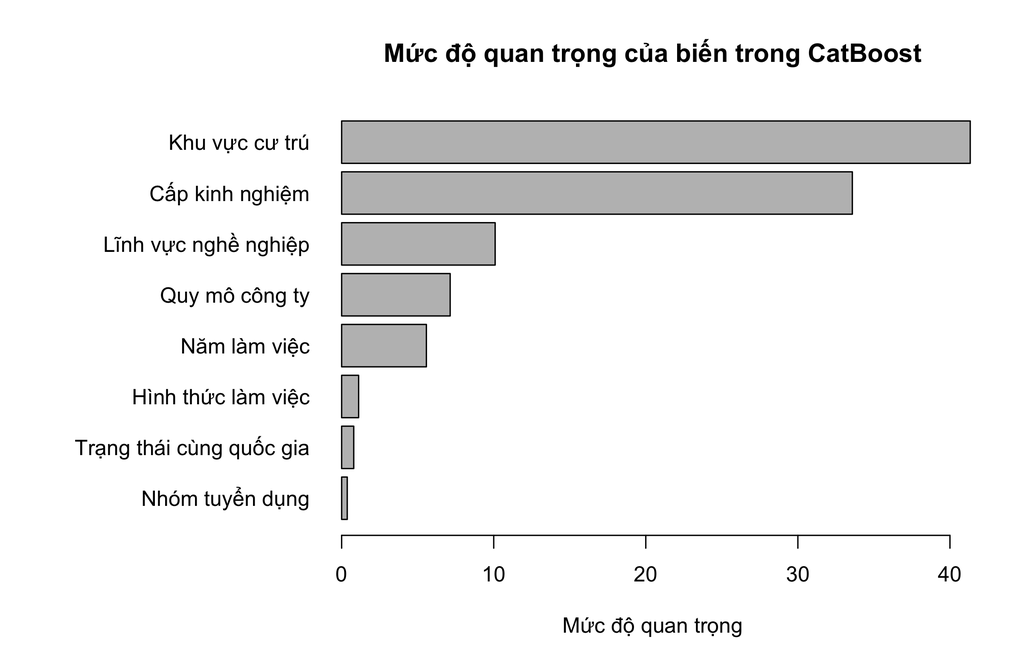

```r
old_par <- par(
  no.readonly = TRUE
)

par(
  mar = c(5, 13, 4, 2) + 0.1
)

barplot(
  height = rev(
    catboost_importance$Importance
  ),
  names.arg = rev(
    catboost_importance$Variable
  ),
  horiz = TRUE,
  las = 1,
  xlab = "Mức độ quan trọng",
  main = "Mức độ quan trọng của biến trong CatBoost"
)
```

```r
par(old_par)
```

Khu vực cư trú có mức độ quan trọng cao nhất, bằng 41,33, tiếp theo là cấp kinh nghiệm với 33,58 và lĩnh vực nghề nghiệp với 10,09. Ba biến này chiếm phần lớn tổng điểm quan trọng của mô hình. Quy mô công ty và năm làm việc đứng ở nhóm tiếp theo, trong khi hình thức làm việc, trạng thái cùng quốc gia và nhóm tuyển dụng có mức độ quan trọng thấp hơn.

Thứ hạng này nhất quán với OLS và EDA ở việc khu vực cư trú cùng cấp kinh nghiệm là hai nhóm thông tin nổi bật nhất. Lĩnh vực nghề nghiệp tiếp tục có vai trò đáng kể, trong khi CatBoost dành thêm một phần thông tin cho quy mô công ty và năm làm việc. Kết quả có thể phản ánh khả năng CatBoost sử dụng các biến trong những tổ hợp phân chia khác nhau, nhưng chưa đủ để xác định cụ thể tổ hợp nào tạo ra chênh lệch dự báo.

Giá trị 41,33 của khu vực cư trú không có nghĩa biến này giải thích 41,33% biến thiên của mức lương. PredictionValuesChange không cho biết khu vực nào có mức lương cao hoặc thấp hơn, không có đơn vị USD, không đi kèm p-value và không phải bằng chứng về quan hệ nhân quả. Chiều và độ lớn của các chênh lệch giữa nhóm vẫn được diễn giải chủ yếu từ OLS; feature importance không được dùng để loại biến hoặc chạy lại CatBoost.

## 23.4 Đánh giá ngoài mẫu và thảo luận

Khả năng dự báo của mô hình được đánh giá trên 113 quan sát thuộc validation set, sử dụng cùng RMSE, MAE, MAPE và R² như các mô hình hồi quy. Bốn chỉ số được tính từ dự báo chưa làm tròn và mức lương thực tế trên thang USD gốc.

```r
catboost_validation_result <- data.frame(
  Model = "CatBoost",
  RMSE = RMSE(
    y_validation_catboost,
    pred_catboost
  ),
  MAE = MAE(
    y_validation_catboost,
    pred_catboost
  ),
  MAPE = MAPE(
    y_validation_catboost,
    pred_catboost
  ),
  R2 = R2(
    y_validation_catboost,
    pred_catboost
  )
)

catboost_validation_result
```

| Model | RMSE | MAE | MAPE | R2 |
| --- | --- | --- | --- | --- |
| CatBoost | 52942.54 | 34824.35 | 60.85503 | 0.3812631 |

Trên validation set, CatBoost đạt RMSE khoảng $52,943 và MAE khoảng $34,824. RMSE đặt trọng số lớn hơn cho các sai số lớn, trong khi MAE cho biết độ lệch tuyệt đối trung bình giữa dự báo và mức lương thực tế vào khoảng $34,824. R² bằng 0,3813 cho thấy mô hình giải thích được khoảng 38,1% biến thiên mức lương ngoài mẫu so với phương án dùng mức lương trung bình thực tế của validation set làm dự báo cho mọi quan sát.

MAPE bằng 60,86% tương đối cao và cần được đọc thận trọng vì chỉ số nhạy với các quan sát có mức lương thực tế thấp. Kết quả cho thấy việc đạt RMSE thấp nhất không đồng nghĩa CatBoost có sai số tỷ lệ tốt nhất ở mọi phân đoạn mức lương. RMSE trên validation set cao hơn CV-RMSE trung bình khoảng $1,325; hai giá trị được tính trên các tập quan sát khác nhau nên không tạo thành một phép kiểm định trực tiếp. Chênh lệch này không lớn so với độ lệch chuẩn giữa các fold, cho thấy kết quả validation chưa tách rời hoàn toàn mức hiệu quả quan sát được trong cross-validation.

Bảng tổng hợp giữ nguyên ba kết quả hồi quy ở Phần 6 và bổ sung CatBoost để so sánh bốn mô hình trên cùng validation set.

```r
final_validation_result <- rbind(
  validation_result,
  catboost_validation_result
)

row.names(final_validation_result) <- NULL

ridge_result <- final_validation_result[
  final_validation_result$Model ==
    "Ridge Regression",
  ,
  drop = FALSE
]

catboost_result <- final_validation_result[
  final_validation_result$Model ==
    "CatBoost",
  ,
  drop = FALSE
]

catboost_rmse_change <- (
  ridge_result$RMSE -
    catboost_result$RMSE
)

catboost_rmse_change_percent <- (
  catboost_rmse_change /
    ridge_result$RMSE
) * 100

final_best_model <- final_validation_result$Model[
  which.min(final_validation_result$RMSE)
]

final_validation_result
```

| Model | RMSE | MAE | MAPE | R2 |
| --- | --- | --- | --- | --- |
| OLS | 53339.41 | 35204.30 | 56.99144 | 0.3719520 |
| Ridge Regression | 53172.54 | 34948.09 | 59.50827 | 0.3758754 |
| LASSO Regression | 53338.39 | 34934.42 | 62.74898 | 0.3719760 |
| CatBoost | 52942.54 | 34824.35 | 60.85503 | 0.3812631 |

CatBoost đạt RMSE thấp nhất và giảm khoảng $230 so với Ridge Regression, tương ứng 0,43%. MAE giảm khoảng $124 và R² tăng từ 0,3759 lên 0,3813, nên hai chỉ số này ủng hộ CatBoost nhẹ. Ngược lại, MAPE của CatBoost bằng 60,86%, cao hơn 59,51% của Ridge Regression khoảng 1,35 điểm phần trăm. Các thước đo vì vậy không tạo ra một thứ tự hoàn toàn đồng nhất.

Mức cải thiện RMSE 0,43% là rất nhỏ so với quy mô sai số chung khoảng $53,000. CatBoost và Ridge Regression nên được xem là có hiệu quả dự báo gần tương đương trong phép chia dữ liệu hiện tại, thay vì coi độ phức tạp của mô hình cây là một ưu thế thực tiễn rõ ràng. CatBoost được chọn theo tiêu chí RMSE đã xác định trước, còn Ridge Regression vẫn là phương án đơn giản hơn, dễ tái lập và phù hợp khi ưu tiên khả năng giải thích.

Khả năng biểu diễn quan hệ phức tạp hơn không bảo đảm hiệu quả tốt hơn khi chỉ có 452 quan sát để huấn luyện và các biến đầu vào chủ yếu là những nhóm phân loại rộng. Những thông tin chi tiết như số năm kinh nghiệm thực tế, kỹ năng, trình độ học vấn, địa điểm cụ thể và đặc điểm doanh nghiệp không có trong dữ liệu; giới hạn thông tin đầu vào có thể quan trọng hơn khác biệt về độ phức tạp giữa thuật toán. Chênh lệch nhỏ cũng có thể thay đổi dưới một phép chia training–validation khác, nên kết luận không được khái quát thành CatBoost luôn tốt hơn Ridge Regression.

Nhìn chung, CatBoost đạt RMSE thấp nhất theo tiêu chí đã xác định trước, nhưng mức cải thiện nhỏ và không đồng nhất giữa các chỉ số. Kết quả vì vậy cần được xem xét cùng ưu điểm về tính đơn giản, khả năng tái lập và khả năng diễn giải của Ridge Regression. Kết luận tổng hợp đối với hai câu hỏi nghiên cứu được trình bày trong phần tiếp theo.

# 24 Kết luận và hướng nghiên cứu tiếp theo

## 24.1 Kết luận

**Đối với Câu hỏi nghiên cứu 1,** Ridge Regression đạt RMSE thấp nhất trong ba mô hình hồi quy và được lựa chọn làm mô hình hồi quy đại diện theo tiêu chí đã xác định trước. Mức cải thiện so với OLS và LASSO Regression chỉ khoảng 0,31%, vì vậy ba mô hình có hiệu quả gần tương đương và Ridge Regression không vượt trội rõ ràng về mặt thực tiễn. OLS vẫn phù hợp hơn cho mục tiêu diễn giải vì hệ số cho biết trực tiếp chiều và độ lớn của chênh lệch mức lương dự kiến giữa các nhóm.

**Đối với Câu hỏi nghiên cứu 2,** CatBoost đạt RMSE thấp nhất trong bốn mô hình và giảm khoảng $230, tương ứng 0,43%, so với Ridge Regression. CatBoost vì vậy được lựa chọn làm mô hình dự báo cuối cùng theo tiêu chí RMSE. Dù vậy, mức cải thiện nhỏ và thứ tự không hoàn toàn đồng nhất giữa các chỉ số bổ sung cho thấy CatBoost chưa tạo ra ưu thế rõ ràng về mặt thực tiễn. Ridge Regression vẫn là phương án thay thế hợp lý khi ưu tiên một mô hình đơn giản, dễ tái lập và dễ diễn giải.

**Xét về các đặc điểm liên hệ với mức lương,** cấp kinh nghiệm và khu vực cư trú tạo ra những chênh lệch nổi bật nhất theo ước lượng OLS. Khi giữ các đặc điểm khác không đổi, nhóm Mid-level / Intermediate, Senior-level / Expert và Executive-level / Director có mức lương dự kiến cao hơn nhóm Entry-level / Junior lần lượt khoảng $18,651, $45,462 và $120,498. So với người lao động cư trú tại Bắc Mỹ, mức lương dự kiến của người lao động cư trú tại châu Âu thấp hơn khoảng $68,879, tại châu Á thấp hơn khoảng $85,005 và tại nhóm khu vực khác thấp hơn khoảng $80,870, khi các yếu tố còn lại trong mô hình không thay đổi. Nhóm Data Analytics & Business Intelligence cũng có mức lương dự kiến thấp hơn nhóm Data Science & Research khoảng $36,175 trong cùng điều kiện so sánh. Lĩnh vực nghề nghiệp và quy mô công ty cũng cung cấp thông tin nhưng kém nổi bật hơn. Việc CatBoost tiếp tục xếp khu vực cư trú, cấp kinh nghiệm và lĩnh vực nghề nghiệp vào nhóm biến quan trọng nhất cho thấy sự nhất quán về vai trò dự báo của các nhóm thông tin này dưới hai cấu trúc mô hình khác nhau.

Nhìn chung, cả bốn mô hình chỉ đạt khả năng dự báo ở mức vừa phải, với RMSE quanh $53,000 và MAE quanh $35,000. Việc chuyển từ các mô hình hồi quy sang CatBoost chỉ tạo ra mức cải thiện nhỏ, cho thấy mô hình phức tạp hơn không tự động đem lại lợi ích dự báo lớn trong bộ dữ liệu hiện tại. Do đó, lựa chọn mô hình cần cân bằng giữa sai số ngoài mẫu, độ ổn định và khả năng diễn giải. Các chênh lệch mức lương được ghi nhận phản ánh mối liên hệ thống kê và vai trò dự báo, không phải tác động nhân quả.

## 24.2 Hạn chế của nghiên cứu

Bộ dữ liệu chỉ gồm 565 quan sát, trong đó 452 quan sát được dùng để huấn luyện, và chỉ bao phủ ba năm 2020–2022. Một số mức nghề nghiệp, hình thức tuyển dụng và khu vực đã được gộp để hạn chế các nhóm quá thưa. Việc gộp nhóm hỗ trợ độ ổn định của mô hình nhưng có thể làm mất những khác biệt chi tiết giữa các vị trí công việc và khu vực địa lý. Vì vậy, mẫu hiện tại không được xem là đại diện đầy đủ cho toàn bộ thị trường lao động khoa học dữ liệu trên phạm vi toàn cầu.

Dữ liệu không có nhiều thông tin có thể liên quan đến mức lương như số năm kinh nghiệm thực tế, trình độ học vấn, kỹ năng và công nghệ chuyên môn, quốc gia hoặc thành phố cụ thể, lĩnh vực hoạt động và đặc điểm của doanh nghiệp, cũng như trách nhiệm và cấp bậc công việc chi tiết. Các cá nhân có đặc điểm nghề nghiệp khác nhau đáng kể do đó vẫn có thể được xếp chung vào những nhóm phân loại rộng. Sự thiếu vắng các thông tin này có thể hạn chế mức hiệu quả dự báo mà cả mô hình tuyến tính và mô hình cây có thể đạt được. Tuy nhiên, chưa có căn cứ từ phân tích hiện tại để khẳng định việc bổ sung riêng một biến nào chắc chắn sẽ cải thiện kết quả.

Kết quả đánh giá cuối cùng dựa trên một lần chia ngẫu nhiên thành training set và validation set. Mặc dù 10-fold cross-validation được sử dụng bên trong training set để lựa chọn tham số, validation set dùng cho đánh giá cuối cùng vẫn chỉ gồm 113 quan sát. Chênh lệch RMSE 0,43% giữa CatBoost và Ridge Regression có thể thay đổi dưới một phép chia dữ liệu khác, nên thứ tự hiện tại cần được diễn giải thận trọng. Nghiên cứu cũng chưa thực hiện external validation trên một bộ dữ liệu độc lập để đánh giá khả năng khái quát sang bối cảnh khác.

Biến mục tiêu có phân phối lệch phải và các mức lương cao hợp lý vẫn được giữ lại như những quan sát hợp lệ. Mô hình chính sử dụng thang lương gốc để duy trì khả năng diễn giải trực tiếp bằng USD, nhưng lựa chọn này có thể đi kèm phần dư đuôi nặng và làm RMSE nhạy hơn với một số sai số lớn. Lưới CatBoost được giới hạn để phù hợp với quy mô dữ liệu, nên chưa bao phủ toàn bộ không gian siêu tham số, còn PredictionValuesChange chỉ cung cấp thứ hạng quan trọng tương đối chứ không cho biết chiều liên hệ. Cuối cùng, dữ liệu quan sát và thiết kế dự báo không cho phép suy luận các mối quan hệ nhân quả.

## 24.3 Hướng nghiên cứu tiếp theo

Các nghiên cứu tiếp theo có thể mở rộng số năm quan sát và quy mô mẫu, đồng thời bổ sung số năm kinh nghiệm thực tế, trình độ học vấn, kỹ năng chuyên môn, công nghệ sử dụng, địa điểm cụ thể, ngành hoạt động và đặc điểm doanh nghiệp cùng trách nhiệm công việc. Những biến chi tiết hơn có thể giúp phân biệt các cá nhân hiện đang được xếp chung trong những nhóm nghề nghiệp, kinh nghiệm hoặc khu vực tương đối rộng. Việc thu thập dữ liệu cũng cần duy trì quy tắc chuẩn hóa nhất quán để các kết quả có thể so sánh qua thời gian. Các đề xuất này cần được đánh giá thực nghiệm thay vì giả định trước rằng mọi biến bổ sung đều cải thiện dự báo.

Độ ổn định của thứ hạng mô hình có thể được kiểm tra bằng repeated cross-validation và bằng cách lặp phép chia training–validation qua nhiều random seed. Nếu việc điều chỉnh tham số và so sánh mô hình được thực hiện đồng thời trên quy mô lớn hơn, nested cross-validation có thể giúp tách rõ quá trình lựa chọn khỏi quá trình ước lượng hiệu quả. External validation trên một bộ dữ liệu độc lập sẽ cung cấp bằng chứng trực tiếp hơn về khả năng khái quát. Khi có đủ dữ liệu nhiều năm, thiết kế huấn luyện trên các năm trước và dự báo một năm sau cũng phù hợp để đánh giá khả năng dự báo theo thời gian; các phân tích này chưa được thực hiện trong báo cáo hiện tại.

Một hướng phân tích độ nhạy là so sánh mô hình trên thang lương gốc với mô hình sử dụng log của mức lương. Dự báo từ thang log cần được chuyển ngược về USD bằng phương pháp hiệu chỉnh phù hợp và mọi phương án phải được đánh giá trên cùng thang USD gốc. Tùy mục tiêu sử dụng, MAE, Huber loss hoặc quantile loss có thể được xem xét để giảm mức chi phối của các sai số rất lớn hoặc để dự báo các phân vị lương. Khoảng dự báo và phân vị dự báo cũng có thể cung cấp thông tin về bất định tốt hơn một dự báo điểm duy nhất; chưa có phương án nào trong số này được đánh giá ở phân tích hiện tại.

Lưới CatBoost có thể được mở rộng một cách có kiểm soát khi có thêm dữ liệu, đồng thời so sánh với các phương pháp boosting khác trong một thiết kế đánh giá thống nhất. SHAP hoặc partial dependence có thể hỗ trợ nghiên cứu chiều và cấu trúc của các quan hệ phi tuyến, còn interaction importance có thể được dùng để khảo sát những tổ hợp như cấp kinh nghiệm với khu vực hoặc cấp kinh nghiệm với lĩnh vực nghề nghiệp. Những công cụ này mô tả cấu trúc dự báo của mô hình, không tạo ra bằng chứng nhân quả. Việc mở rộng khả năng giải thích cũng không nên sử dụng validation set để lựa chọn lại mô hình sau khi đã xem kết quả ngoài mẫu.

Các hướng mở rộng trên không chỉ nhằm giảm sai số dự báo mà còn giúp đánh giá tính ổn định, khả năng khái quát và giá trị diễn giải của mô hình trong những bối cảnh dữ liệu khác. Một thiết kế đánh giá chặt chẽ hơn sẽ cho biết liệu chênh lệch nhỏ giữa CatBoost và Ridge Regression có được duy trì khi dữ liệu hoặc cách phân chia thay đổi hay không. Đồng thời, dữ liệu giàu thông tin hơn có thể làm rõ giới hạn hiện tại xuất phát từ đặc trưng đầu vào hay từ cấu trúc của mô hình.

# 25 Tài liệu tham khảo

CatBoost. (n.d.). *CatBoost documentation*. Retrieved July 29, 2026, from https://catboost.ai/docs/en/

Hastie, T., Tibshirani, R., & Friedman, J. (2009). *The elements of statistical learning: Data mining, inference, and prediction* (2nd ed.). Springer. https://doi.org/10.1007/978-0-387-84858-7

Hastie, T., Tibshirani, R., & Wainwright, M. (2015). *Statistical learning with sparsity: The lasso and generalizations*. CRC Press. https://doi.org/10.1201/b18401

James, G., Witten, D., Hastie, T., & Tibshirani, R. (2021). *An introduction to statistical learning: With applications in R* (2nd ed.). Springer. https://doi.org/10.1007/978-1-0716-1418-1

Prokhorenkova, L., Gusev, G., Vorobev, A., Dorogush, A. V., & Gulin, A. (2018). CatBoost: Unbiased boosting with categorical features. *Advances in Neural Information Processing Systems, 31*, 6638–6648. https://proceedings.neurips.cc/paper/2018/hash/14491b756b3a51daac41c24863285549-Abstract.html